# Эксперимент РНЦХ: первичная идентификация CSV и визуализация протокола

**Дата записей:** 15.07.2026  
**Папка эксперимента:** `EXP_2026_07_16_RNCH_RKM_PULMOVISTA_NIX`  
**Система:** реокардиомонитор, два канала: ТТРКГ на руках и боковая сборка 140/70 мм над правым лёгким/мягкими тканями.

Цель первой версии — определить принадлежность CSV, убрать физические дубликаты и показать записи, явно описанные в протоколе. Точные границы дыхательных манёвров в CSV не записаны; цветная разметка ниже является **ориентировочной реконструкцией по протоколу и форме сигнала**, а не исходной событийной разметкой.

## 1. Инвентаризация и соответствие файлов

Файлы с одинаковым SHA-256 считаются физическими копиями одной записи. Для анализа выбирается каноническая копия с самым коротким относительным путём.

| Время | CSV | Длительность, с | Частота, Гц | Копий | Назначение | Связь с протоколом | Уверенность | Основание |
| --- | --- | --- | --- | --- | --- | --- | --- | --- |
| 13:39:22 | 2026-07-15 13-39-22 162 rcm.csv | 6.220000 | 200.000000 | 1 | Настройка, короткий фрагмент | не входит | высокая | 6.2 с; только BASE1; QS обоих каналов на потолке 4700 |
| 13:39:32 | 2026-07-15 13-39-32 296 rcm.csv | 107.420000 | 200.000000 | 1 | Предварительная запись канала 1 | не входит | средняя | 107.4 с; только BASE1≈73 Ом; в протоколе не упомянута |
| 13:57:33 | 2026-07-15 13-57-33 517 rcm.csv | 34.420000 | 200.000000 | 1 | Настройка перед основными пробами | не входит | средняя | 34.4 с; BASE1≈61 Ом, BASE2≈0; в протоколе не упомянута |
| 14:07:01 | 2026-07-15 14-07-01 532 rcm.csv | 67.420000 | 200.000000 | 2 | ТТРКГ, канал 1 отдельно | описан | высокая | время и длительность совпадают; BASE2=0 |
| 14:09:42 | 2026-07-15 14-09-42 452 rcm.csv | 69.220000 | 200.000000 | 2 | Боковой канал 2 отдельно | описан | высокая | время и длительность совпадают; BASE1=0 |
| 14:17:16 | 2026-07-15 14-17-16 541 rcm.csv | 46.020000 | 200.000000 | 2 | Поочерёдное отключение каналов | описан как 14:08 | высокая | видна последовательность оба→2→оба→1→оба |
| 14:19:52 | 2026-07-15 14-19-52 727 rcm.csv | 73.620000 | 200.000000 | 2 | Оба канала: дыхательный протокол | описан как 14:17 | высокая | 73.6 с и структура 30 с дыхания→задержка→3 цикла→задержка |

### Главный результат сопоставления

- `14-07-01` — отдельный канал 1, ТТРКГ.
- `14-09-42` — отдельный канал 2, боковая сборка.
- `14-17-16` — тест отключения каналов, хотя в тексте протокола для него указано 14:08.
- `14-19-52` — совместный дыхательный протокол, хотя в тексте указано 14:17.
- Последние четыре CSV продублированы байт-в-байт в корне `TTRKG_and_SIDE` и в подпапке `2026-07-15`; на графиках каждая запись показана один раз.

Таким образом, наиболее вероятна не потеря файлов, а сдвиг времён двух последних пунктов в рукописном описании протокола.

## 2. ТТРКГ, канал 1 отдельно — `14-07-01`

По протоколу: свободное дыхание 30 с, вдох и задержка около 15 с, форсированное дыхание, задержка на выдохе. Границы после 30-й секунды отмечены ориентировочно.

| Канал | BASE median, Ом | BASE p01–p99, Ом | QS median, Ом | QS=4700, % | RHEO p01–p99, мОм |
| --- | --- | --- | --- | --- | --- |
| 1 | 101.350000 | 100.29–102.49 | 4700.000000 | 100.000000 | -584.5–584.2 |

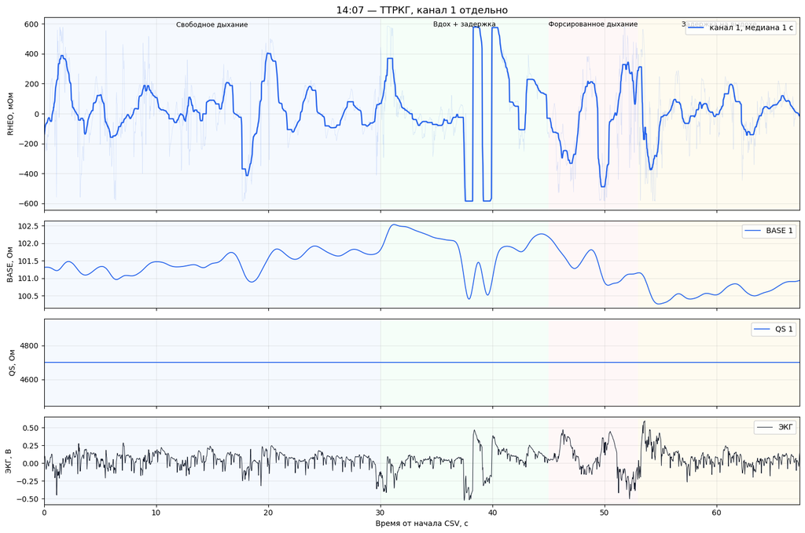

**Наблюдение:** `BASE1≈101 Ом`, а не около 80 Ом, указанных в примечании протокола. `QS1=4700 Ом` на всей записи — это тот же потолок, который наблюдается у отключённых каналов; поэтому запись нужно считать потенциально перегруженной/некорректно согласованной, пока не будет расшифрована шкала QS прибора.

## 3. Боковая сборка, канал 2 отдельно — `14-09-42`

По протоколу: свободное дыхание 30 с, задержка на вдохе около 15 с, три форсированных цикла, задержка на выдохе. Три крупных цикла хорошо видны около 49–59 с.

| Канал | BASE median, Ом | BASE p01–p99, Ом | QS median, Ом | QS=4700, % | RHEO p01–p99, мОм |
| --- | --- | --- | --- | --- | --- |
| 2 | 37.160000 | 35.95–40.08 | 343.000000 | 0.000000 | -505.7–505.4 |

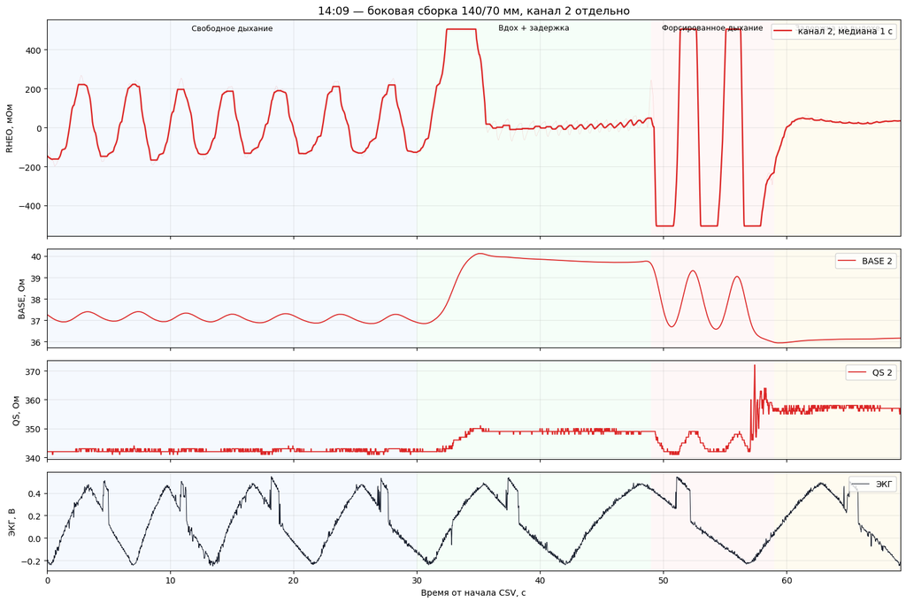

**Наблюдение:** `BASE2≈37.2 Ом` согласуется с указанными в протоколе 36 Ом. `QS2≈343 Ом` стабилен и не достигает потолка 4700. Канал 1 в этой записи действительно отключён (`BASE1=0`).

## 4. Поочерёдное отключение каналов — фактически `14-17-16`

Состояния определены автоматически по условию `BASE>5 Ом`. Переходы полностью совпадают с описанным тестом: сначала оба канала, затем отключён первый, снова оба, затем отключён второй, в конце снова оба.

| Начало, с | Конец, с | Активны | BASE1 median, Ом | BASE2 median, Ом | QS1 median, Ом | QS2 median, Ом |
| --- | --- | --- | --- | --- | --- | --- |
| 0.000000 | 12.080000 | оба | 54.160000 | 40.860000 | 1371.000000 | 368.000000 |
| 12.080000 | 22.990000 | только 2 | 0.000000 | 36.880000 | 4700.000000 | 357.000000 |
| 23.000000 | 34.020000 | оба | 54.190000 | 40.900000 | 1284.000000 | 368.000000 |
| 34.030000 | 42.800000 | только 1 | 92.690000 | 0.000000 | 4700.000000 | 4700.000000 |
| 42.810000 | 46.020000 | оба | 54.330000 | 33.360000 | 1280.000000 | 368.000000 |

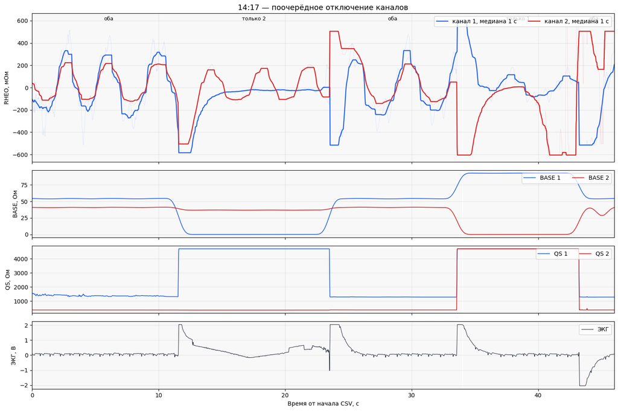

**Наблюдение:** при совместной работе `BASE1≈54 Ом`, `BASE2≈41 Ом`; при отключении первого `BASE1=0`, а второй остаётся около 37 Ом; при отключении второго `BASE2=0`, а первый возрастает примерно до 93 Ом. Это количественно подтверждает взаимное влияние каналов. Значение `QS=4700` появляется у отключённого канала и у канала 1 при его одиночной работе, поэтому его следует рассматривать как индикатор предельного/нештатного состояния.

## 5. Оба канала: дыхательный протокол — фактически `14-19-52`

Структура записи соответствует протоколу: около 30 с свободного дыхания, вдох и задержка, три форсированных цикла, затем задержка на выдохе.

| Канал | BASE median, Ом | BASE p01–p99, Ом | QS median, Ом | QS=4700, % | RHEO p01–p99, мОм |
| --- | --- | --- | --- | --- | --- |
| 1 | 54.420000 | 52.96–58.22 | 1307.000000 | 0.000000 | -516.8–516.1 |
| 2 | 40.720000 | 39.65–44.19 | 368.000000 | 0.000000 | -505.7–505.4 |

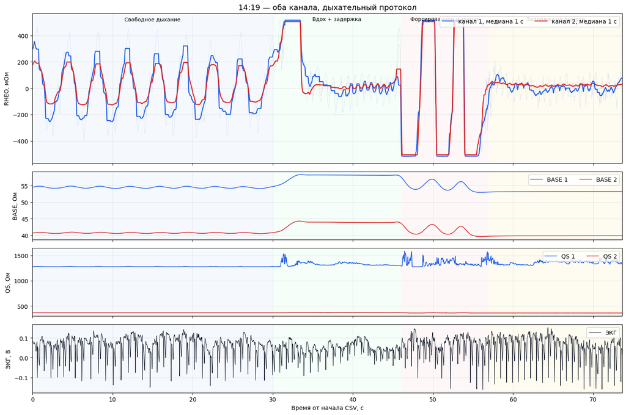

**Наблюдение:** при совместной работе медианы составляют примерно `BASE1=54.4 Ом` и `BASE2=40.7 Ом`; второй уровень хорошо совпадает с протоколом, первый ниже ожидаемых 60 Ом, но близок по порядку. `QS1≈1307 Ом`, `QS2≈368 Ом`, без выхода на потолок 4700. Оба RHEO-сигнала синхронно отражают дыхательные манёвры, но на форсированных вдохах/выдохах достигают ограничения диапазона.

## 6. Выводы первой итерации

1. Четыре протокольные записи идентифицированы с высокой уверенностью; два времени в текстовом протоколе, вероятно, записаны неточно.
2. Анализировать следует уникальные SHA-256, иначе четыре основные записи будут посчитаны дважды.
3. Наиболее чистая одиночная запись — боковой канал `14-09-42`: базовый импеданс согласуется с протоколом, QS стабилен.
4. Одиночная запись ТТРКГ `14-07-01` требует осторожности: BASE выше ожидаемого, QS находится на потолке.
5. Тест `14-17-16` доказывает взаимное влияние каналов: базовые уровни существенно меняются при отключении соседнего канала.
6. Для следующей итерации нужны расшифровка физического смысла и допустимых диапазонов QS, а также подтверждение границ дыхательных этапов по журналу/видео или ручным меткам оператора.